# The ethical engineer - ‘depends on what it is’

David Reichel

This is the code for analysis of the blog post - the ethical engineer. It includes analysis of survey data and then matching some country level results.

The first chunk loads libraries and defines some objects needed.

```r
knitr::opts_chunk$set(echo = TRUE, warnings = FALSE, message = FALSE)
library(tidyverse)
library(broom)
theme_set(theme_bw())
library(countrycode)
library(knitr)
library(lme4)
library(openxlsx)
EUlist2 <- c("AT","BE","BG","HR","CY",
             "CZ","DK","EE","FI",
             "FR","DE","EL","HU",
             "IE","IT","LV","LT",
             "LU","MT","NL","PL",
             "PT","RO","SK","SI",
             "ES","SE","UK")

## helper function for coeficient plots from regressions
plot.coef <- function(df) {
  df <- dplyr::filter(df, group == "fixed")
  ggplot(df, aes(estimate, term)) +
    geom_vline(xintercept = 0, linetype = 2) +
    geom_segment(aes(x = estimate - 2.576*std.error,
                     xend = estimate + 2.576*std.error,
                     y = term, yend = term), size = 1, alpha = 0.6) +
    geom_segment(aes(x = estimate - 1.96*std.error,
                     xend = estimate + 1.96*std.error,
                     y = term, yend = term), size = 1, alpha = 0.8) +
    geom_point(size = 2)
}
```

The next chunk loads the data of the [Stack Overflow](https://stackoverflow.com/) developer survey 2018, available from here: https://insights.stackoverflow.com/survey/2018/. I first loaded the full dataset, recoded some variables as needed for the analysis and then saved a reduced dataset. I proceed with some descriptive statistics calculating the basic descriptives (tables) for the post. I store them as objects to use them in the blog/R markdown in the blogpost.

```r
## source information: https://insights.stackoverflow.com/survey/2018/
# data preparation
dat <- read.csv("survey_results_public.csv",
                stringsAsFactors = FALSE)

# some recoding
dat$iso2 <- countrycode(dat$Country, "country.name", "iso2c") %>% suppressWarnings()
```

```
Some values were not matched unambiguously: Other Country (Not Listed Above)
```

```r
dat <- dat %>%
  mutate(EU = as.integer(iso2 %in% c(EUlist2, "GB", "GR")),
         unethical = ifelse(EthicsChoice == "Yes", 1, 0),
         ethical = ifelse(EthicsChoice == "No", 1, 0),
         Gender = ifelse(Gender == "Male", "Male",
                     ifelse(Gender == "Female", "Female", "Other")),
         white = ifelse(RaceEthnicity == "White or of European descent", 1, 0),
         CareerSatisfaction = ifelse(CareerSatisfaction %in% c("Extremely dissafisfied",
                                                         "Moderately dissatisfied",
                                                         "Slightly dissatisfied"),
                               "Dissatisfied", "Not dissatisfied"),
         Age = fct_relevel(Age, "Under 18 years old")) %>%
  dplyr::select(EthicsChoice, unethical, ethical,
                EthicsReport, EthicsResponsible, EthicalImplications,
                     Gender, Age, white,
                     YearsCoding, CareerSatisfaction,
                     Employment, FormalEducation,
                     iso2, EU)

# write.csv(dat, file = "survey_results_public_reduced.csv", row.names = FALSE)
#
# dat <- read.csv("survey_results_public_reduced.csv", stringsAsFactors = FALSE)

# The following questions were asked, which will be analysed:
# Imagine that you were asked to write code for a purpose or product that
# you consider extremely unethical. Do you write the code anyway?
t1 <- count(dat, EthicsChoice) %>%
  na.omit() %>%
  mutate(percentage = round(100*(n / sum(n)), 1))

t2_tit <- "Do you report or otherwise call out the unethical code in question?"
t2 <- count(dat, EthicsReport) %>%
  na.omit() %>%
  mutate(percentage = round(100*(n / sum(n)), 1))

t3_tit <- "Who do you believe is ultimately most responsible for code that accomplishes something unethical?"
t3 <- count(dat, EthicsResponsible) %>%
  na.omit() %>%
  mutate(percentage = round(100*(n / sum(n)), 1))

# Ethics obligation EthicalImplications,
t4_tit <- "Do you believe that you have an obligation to consider the ethical implications of the code that you write?"
t4 <- count(dat, EthicalImplications) %>%
  na.omit() %>%
  mutate(percentage = round(100*(n / sum(n)), 1))
```

Now the first graph with ggplot2.

```r
p1 <- ggplot(t1) +
  geom_col(aes(reorder(EthicsChoice, percentage), percentage)) +
  geom_text(aes(reorder(EthicsChoice, percentage), percentage,
                 label = paste(EthicsChoice, "\n (", percentage, "%)")), vjust = -0.3) +
  scale_y_continuous(limits = c(0,75)) +
  labs(y = "Percentage", x = "",
       title = "Figure 1: Developers willing to write unethical code",
       caption = paste0("Question: Imagine that you were asked to write code for a purpose or product that you consider extremely unethical.\nDo you write the code anyway?, \n Own calculations based on Stack Overflow Developer Survey 2018, N = ", sum(t1$n))) +
  theme(axis.text.x = element_blank(), axis.ticks.x = element_blank())
```

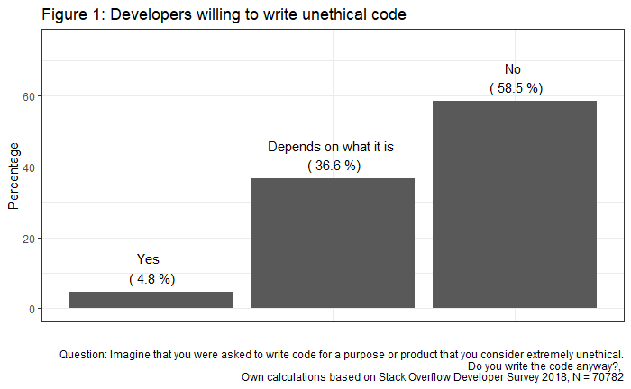

```r
p1
```

The I run the basic regression. I did a few tests of different models (e.g. without country included, with country as fixed effects, etc.) Finally, I settled for the one you see below with modelling the country as a varying intercept (hence assuming that the share varies across countries following a normal distribution). As I did not want the rendering of the blog post taking too long, I saved the model out first and then loaded the data I needed for the graph.

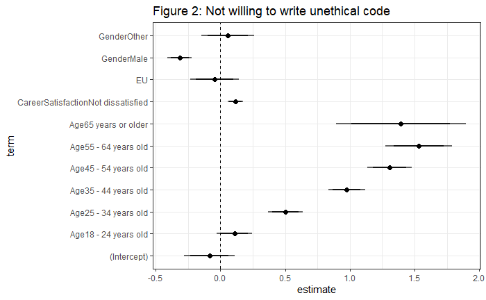

```r
# m2a <- glmer(ethical ~ Gender + Age + # white +
#             CareerSatisfaction + EU + (1 | iso2),
#           data = dat,
#           family = binomial(link = "logit"))
# m2a <- tidy(m2a)
# write.csv(m2a, file = "m2a.csv", row.names = FALSE)

m2a <- read.csv("m2a.csv", stringsAsFactors = FALSE)

plot.coef(m2a) + labs(title = "Figure 2: Not willing to write unethical code")
```

Table 1.

```r
kable(t2, caption = paste("Table 1:", t2_tit))
```

| EthicsReport | n | percentage |
| --- | --- | --- |
| Depends on what it is | 32812 | 46.6 |
| No | 3254 | 4.6 |
| Yes, and publicly | 9200 | 13.1 |
| Yes, but only within the company | 25160 | 35.7 |

Table 2.

```r
kable(t4, caption = paste("Table 2:", t4_tit))
```

| EthicalImplications | n | percentage |
| --- | --- | --- |
| No | 4216 | 6.1 |
| Unsure / I don’t know | 9893 | 14.3 |
| Yes | 55200 | 79.6 |